# Automated discrimination

# Variable explanation

The ad reports from Google and Facebook were cleaned and restructured to the same set of variables:

- *country*: the country the ad was targeted for
- *job*: the type of employment ad that was shown
- *gender*: assumed gender of the audience; impressions with unknown gender are filtered out in this report and calculations are based on data points with known gender
- *clicks*: number of clicks on ad — cumulative
- *impressions*: number of times ad was shown — cumulative
- *ctr*: click-through-rate; share of clicks per impression
- *datetime*: date and time of data points; this is based on time of manual downloads of reports every few minutes (at more or less regular intervals)
- *time*: hours passed since first impressions were registered
- *impr_rel*: share of all impressions of an ad at that time

**Note**: For the data for each of the following figures, see the folder “data/output/”, where you’ll also find the full, clean dataset for each country.

# Point 1: Discrimination with no audience targeting

## By Google Ads

[figure not shown]

### Corresponding data

| job | impressions | impr_rel |
| --- | --- | --- |
| Hairdresser | 20885 | 0.5175063 |
| Machine Learning | 7652 | 0.5153903 |
| Child care worker | 19682 | 0.4993277 |
| Legal Counsel | 21732 | 0.4808497 |
| Nurse | 18172 | 0.4593877 |
| Truck driver | 15260 | 0.4187706 |

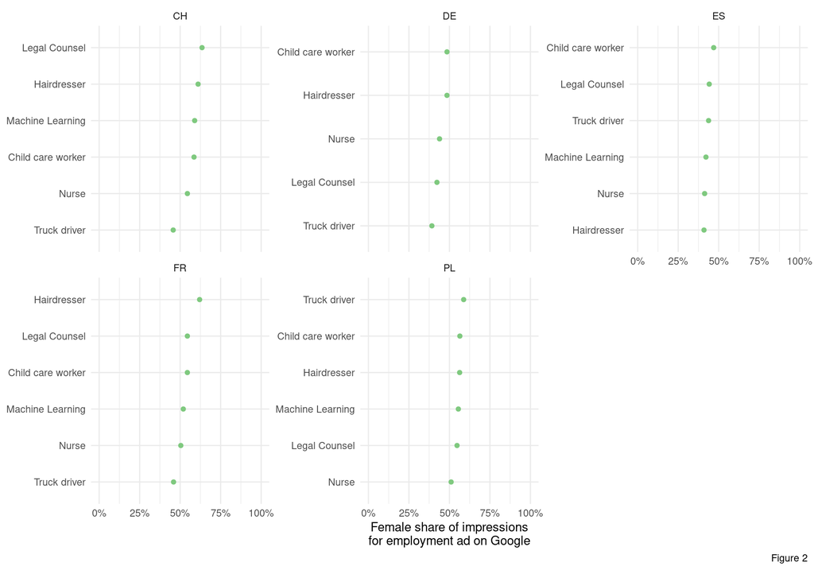

### Corresponding data

| country | job | gender | impr_rel |
| --- | --- | --- | --- |
| CH | Legal Counsel | female | 0.6350778 |
| CH | Hairdresser | female | 0.6106705 |
| CH | Machine Learning | female | 0.5895161 |
| CH | Child care worker | female | 0.5855263 |
| CH | Nurse | female | 0.5446880 |
| CH | Truck driver | female | 0.4570800 |
| DE | Child care worker | female | 0.4850019 |
| DE | Hairdresser | female | 0.4848694 |
| DE | Nurse | female | 0.4389793 |
| DE | Legal Counsel | female | 0.4230477 |
| DE | Truck driver | female | 0.3917341 |
| ES | Child care worker | female | 0.4691298 |
| ES | Legal Counsel | female | 0.4416667 |
| ES | Truck driver | female | 0.4375904 |
| ES | Machine Learning | female | 0.4213511 |
| ES | Nurse | female | 0.4131687 |
| ES | Hairdresser | female | 0.4093249 |
| FR | Hairdresser | female | 0.6200770 |
| FR | Legal Counsel | female | 0.5445414 |
| FR | Child care worker | female | 0.5445363 |
| FR | Machine Learning | female | 0.5193458 |
| FR | Nurse | female | 0.5039818 |
| FR | Truck driver | female | 0.4592849 |
| PL | Truck driver | female | 0.5878443 |
| PL | Child care worker | female | 0.5643585 |
| PL | Hairdresser | female | 0.5630484 |
| PL | Machine Learning | female | 0.5550823 |
| PL | Legal Counsel | female | 0.5469926 |
| PL | Nurse | female | 0.5105584 |

## By Facebook Ads

[figure not shown]

### Corresponding data

| job | gender | impr_rel |
| --- | --- | --- |
| Child care worker | female | 0.8808107 |
| Nurse | female | 0.7954105 |
| Hairdresser | female | 0.5663621 |
| Legal Counsel | female | 0.5340955 |
| Machine Learning | female | 0.4926102 |
| Truck Driver | female | 0.1019857 |

[figure not shown]

### Corresponding data

| country | job | gender | impr_rel |
| --- | --- | --- | --- |
| CH | Child care worker | female | 0.9106487 |
| CH | Nurse | female | 0.6706161 |
| CH | Hairdresser | female | 0.5135135 |
| CH | Legal Counsel | female | 0.4382514 |
| CH | Machine Learning | female | 0.3673835 |
| CH | Truck Driver | female | 0.0780065 |
| DE | Child care worker | female | 0.9623341 |
| DE | Nurse | female | 0.7776848 |
| DE | Machine Learning | female | 0.5694539 |
| DE | Hairdresser | female | 0.4984303 |
| DE | Legal Counsel | female | 0.4934341 |
| DE | Truck Driver | female | 0.0770733 |
| ES | Nurse | female | 0.8273989 |
| ES | Child care worker | female | 0.7077229 |
| ES | Legal Counsel | female | 0.5656276 |
| ES | Hairdresser | female | 0.4963072 |
| ES | Machine Learning | female | 0.4725810 |
| ES | Truck Driver | female | 0.2561158 |
| FR | Child care worker | female | 0.9058409 |
| FR | Nurse | female | 0.7751236 |
| FR | Hairdresser | female | 0.6511628 |
| FR | Legal Counsel | female | 0.5418502 |
| FR | Machine Learning | female | 0.5197912 |
| FR | Truck Driver | female | 0.1175828 |
| PL | Child care worker | female | 0.9432638 |
| PL | Nurse | female | 0.8637261 |
| PL | Hairdresser | female | 0.6708900 |
| PL | Legal Counsel | female | 0.5981171 |
| PL | Machine Learning | female | 0.4288755 |
| PL | Truck Driver | female | 0.0419181 |

# Point 2: Click-through-rate doesn’t influence impressions

## Google

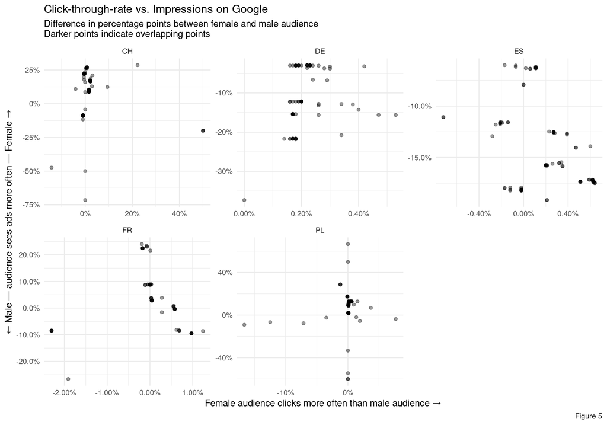

**Note**: Data too large to display here. See “data/output/”.

## Facebook

[figure not shown]

**Note**: Data too large to display here. See “data/output/”.

# Point 3: Ad images influence ad delivery

## On Google

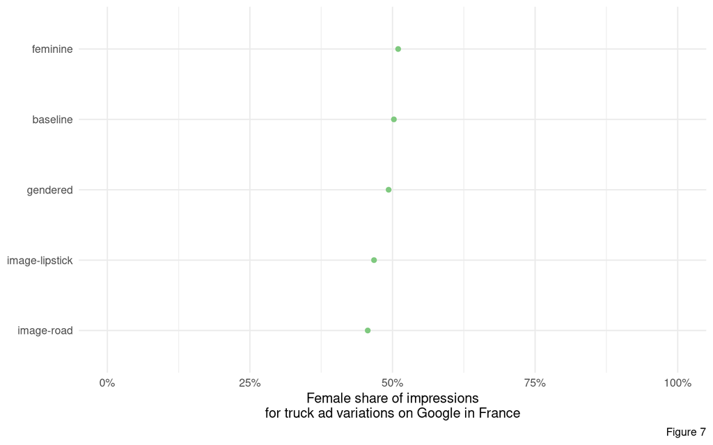

### Corresponding data

| country | job | variation | gender | impr_rel |
| --- | --- | --- | --- | --- |
| FR | Truck driver | feminine | female | 0.5099046 |
| FR | Truck driver | baseline | female | 0.5024240 |
| FR | Truck driver | gendered | female | 0.4931962 |
| FR | Truck driver | image-lipstick | female | 0.4675870 |
| FR | Truck driver | image-road | female | 0.4565783 |

## On Facebook

[figure not shown]

### Corresponding data

| country | job | variation | gender | impr_rel |
| --- | --- | --- | --- | --- |
| FR | Truck Driver | image-lipstick | female | 0.8765771 |
| FR | Truck Driver | image-road | female | 0.5262557 |
| FR | Truck Driver | gendered | female | 0.2202462 |
| FR | Truck Driver | feminine | female | 0.1892944 |
| FR | Truck Driver | baseline | female | 0.1531532 |